# week_5

## Array Manipulation Function

```python
numbers = np.array([1,2,3,4,5,6,7,8,9])
# reshape the 1D array into a 3x3 array
reshaped_array = np.reshape(numbers,(3,3))
print (reshaped_array)
#transpose the array
transposed_array= np.transpose(reshaped_array)
print(transposed_array)
```

```
[[1 2 3]
 [4 5 6]
 [7 8 9]]
[[1 4 7]
 [2 5 8]
 [3 6 9]]
```

```python
numbers=[1,2,3,4]
"""^^^^^^^^^^^^^^^^^^^^^^^^^^^^^^^^^ mathematical funbction^^^^^^^^^^^^^^^^^^^^^^^"""
print ("^^^^^^^^^^^^ mathematical Function^^^^^^^^^^^^^^^^")
students_marks= np.array([30,50,67,10,100,99,98,71,54,34])
mean_marks= np.mean(students_marks)
print("mean:", mean_marks)
#computer the meadian of marks
median_marks= np.median(students_marks)
#find the minimum and maximum marks
min_marks= np.min(students_marks)
print("minimum marks:",min_marks)
max_marks= np.max(students_marks)
print("minimum marks:",max_marks)
std_marks= np.std(students_marks)
print("minimum marks:",std_marks)
```

```
^^^^^^^^^^^^ mathematical Function^^^^^^^^^^^^^^^^
mean: 61.3
minimum marks: 10
minimum marks: 100
minimum marks: 29.883272913119807
```

## NumPy Matrix Operations

• Matrix Multiplication np.matmu1()

• Dot Product np. dot()

• Cross Product np. cross()

• Transpose np. transpose

• Inverse np. linalg. inverse()

• Determinant linalg.det() linalg=>Linear Algebra

. Norm np.linalg.norm()

. trace np.linalg.trace()

```python
mat_1 = [
           [1,2,3],
           [4,5,6]
        ] #2,3
mat_2= [
    [1,2],
    [3,4],
    [4,6],
] # 3,2
result= np.matmul(mat_1,mat_2)
print(result)
#find determinant of matrix
determinant = np.linalg.det(result)
print(determinant)
vec1= [1,2,3]
vec2= [4,5,6]
#dot product
dot_prod= np.dot(vec1,vec2)
print(dot_prod)
# cross product
cross_prod= np.cross(vec1, vec2)
print(cross_prod)
```

```
[[19 28]
 [43 64]]
12.000000000000021
32
[-3  6 -3]
```

• The Sky is Blue

• The Ocean is Blue

Use TD-IDF Algorithm to Vectorize the sentences

TF (t)= total number of occurrence of term t in sentence (doc)/ total length of words in sentence (doc)

IDF(t) = log ( total sentence (doc) length) / no of documents contains term t

tf-idf score = tf * idf

```python
sec1="The sky is Blue".lower()
sec2="The ocean is blue".lower()
vec0=np.array([1,2,3,4])
vec1=np.array([1,5,3,4])
dot_prod=np.dot(vec0,vec1)
similarity=dot_prod/(np.linalg.norm(vec0)*np.linalg.norm(vec1))
print(similarity)
```

```
0.9203579866168444
```

```python
sec1="The sky is Blue".lower()
sec2="AYUSH basnet is happy".lower()
## vec0=np.array([1,2,3,4])
## vec1=np.array([1,5,3,4])
## dot_prod=np.dot(vec0,vec1)
## similarity=dot_prod/(np.linalg.norm(vec0)*np.linalg.norm(vec1))
## print(similarity)

def tf_idf_vectorizer(word,sentence):
    tf=sentence.count(word) / len(sentence.split())
    total_doc_size=2
    idf=np.log(total_doc_size/1 if word in sec1 else 0 +1 if word in sec2 else 0)
    return tf* idf


vec1=np.array([tf_idf_vectorizer(word,sec1) for word in sec1.split()])
vec2= np.array([tf_idf_vectorizer(word,sec2) for word in sec2.split()])

similarity= np.dot(vec1,vec2)/(np.linalg.norm(vec1)*np.linalg.norm(vec2))
print(similarity)
```

```
0.5
```

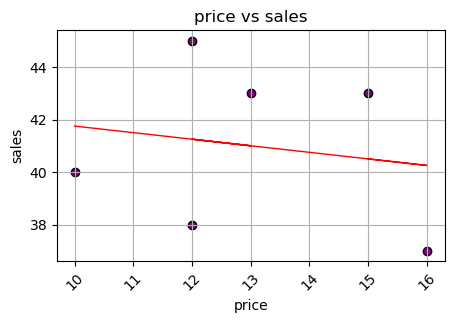

```python
sales_data= pd.DataFrame({
    'price': [10,12,13,12,16,15],
    'sales':[40,38,43,45,37,43]
})
plt.figure(figsize=(5,3))
plt.scatter(
    sales_data['price'],
    sales_data['sales'],
    color='purple',
    edgecolor='black',
)
x = sales_data['price']
y=sales_data['sales']
m,c=np.polyfit(x,y,1)
plt.plot(x ,
         m*x+c, color= 'red',
         linewidth = 1,
)
plt.xticks(rotation=45)
plt.title('price vs sales')
plt.xlabel('price')
plt.ylabel('sales')
plt.grid(True)
```

## Calculate regression

```python
import numpy as np

# Given data
prices = [10, 12, 13, 12, 16, 15]
sales = [40, 38, 43, 45, 37, 43]

# Calculate sums
n = len(prices)
sum_x = sum(prices)
sum_y = sum(sales)
sum_x_squared = sum(x**2 for x in prices)
sum_xy = sum(x * y for x, y in zip(prices, sales))

# Calculate slope (m)
m = (n * sum_xy - sum_x * sum_y) / (n * sum_x_squared - sum_x**2)

# Calculate intercept (b)
c = (sum_y - m * sum_x) / n

# Predict sales when price is 20
price_to_predict = 20
predicted_sales = m * price_to_predict + c

print(f"Predicted sales when price is {price_to_predict}: {predicted_sales}")
```

```
Predicted sales when price is 20: 39.25
```

## sales prediction (marketing - vs- sales)

bulid a multiple linear model which predicts sales based on the money spent on different platforms for marketing

```python
marketing_data=pd.read_csv('./data/marketing-sales.csv')
marketing_data.head()
```

|  | TV | Radio | Newspaper | Sales |
| --- | --- | --- | --- | --- |
| 0 | 230.1 | 37.8 | 69.2 | 22.1 |
| 1 | 44.5 | 39.3 | 45.1 | 10.4 |
| 2 | 17.2 | 45.9 | 69.3 | 12.0 |
| 3 | 151.5 | 41.3 | 58.5 | 16.5 |
| 4 | 180.8 | 10.8 | 58.4 | 17.9 |

## Data cleaning and pre-processiong

. fix data types

. Normalization(if required)

. Handel missing data

. Perform data transformation filtering (if required)

```python
marketing_data= marketing_data.fillna(marketing_data.mean())
```

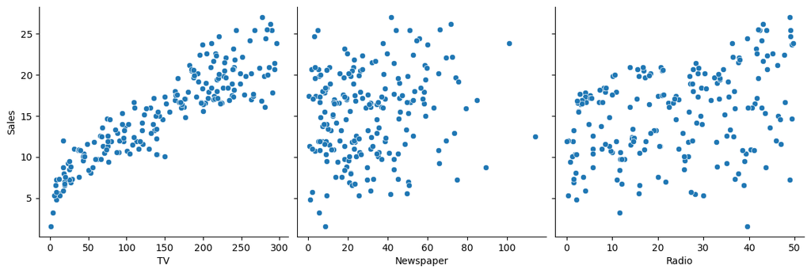

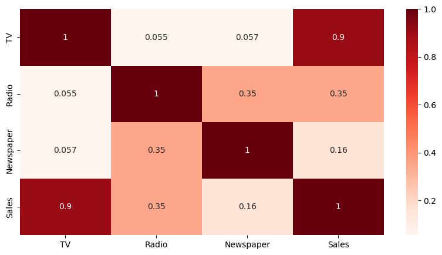

```python
import matplotlib.pyplot as plt
import seaborn as sns

# scattered plot between TV-sales, Newspaper-Sales, Radio-Sales
plt.figure(figsize=(10,5))
sns.pairplot(marketing_data, x_vars=['TV', 'Newspaper', 'Radio'], y_vars='Sales', height=4, aspect=1, kind='scatter')
plt.show()

# Hitmap to find out the correlation between variables
plt.figure(figsize=(10,5))
sns.heatmap(marketing_data.corr(), cmap="Reds", annot= True)
plt.show()
```

## Build Multiple Linear Regression Model

• TV, Radio, Newspaper are features (x1,x2,×3)

• Sales is Label (y)

Prepare Train-Test Dataset

```python
from sklearn.model_selection import train_test_split
# define features(x) and target(y)
x = marketing_data[['TV', 'Radio', 'Newspaper']]
y = marketing_data[ 'Sales']

# split the data into training and testing sets
x_train, x_test, y_train, y_test = train_test_split(x,y,test_size=0.2, random_state=42)
```

## Build Model

```python
from sklearn.linear_model import LinearRegression

# Initialize the model
sales_model = LinearRegression()

#fit data to the model
sales_model.fit(x_train, y_train)

# Print the coefficients
print("Coefficients:", sales_model.coef_)

print("Intercept:", sales_model.intercept_)
```

```
Coefficients: [0.05450927 0.10094536 0.00433665]
Intercept: 4.714126402214131
```

## Evaluate Model

```python
from sklearn.metrics import mean_squared_error
# Make preditions
y_pred = sales_model.predict(x_test)
# Evaluate the model
mse = mean_squared_error(y_test,y_pred)
rmse= mse**1/2
print("mean squared error:",mse,rmse)
```

```
mean squared error: 2.9077569102710905 1.4538784551355453
```

## Inferences (use model in real-word)

```python
tv_ad_cost= 200
radio_ad_cost= 25
news_ad_cost=40
single_data=np.array([tv_ad_cost_ad_cost,news_ad_cost]).reshape(1,3)
print(single_data)
single_prediction= sales_model.predict(single_data)
print(f"Adertising Budget")
```

[output not shown]

```python
import pandas as pd
from sklearn.model_selection import train_test_split
from sklearn.linear_model import LinearRegression
from sklearn.metrics import mean_squared_error
data = pd.read_csv('./data/student-por.csv', sep=';')
X = data[['G1', 'G2', 'studytime', 'absences']]
y = data['G3']
X_train, X_test, y_train, y_test = train_test_split(X, y, test_size=0.2, random_state=42)
model = LinearRegression()
model.fit(X_train, y_train)
y_pred = model.predict(X_test)
mse = mean_squared_error(y_test, y_pred)
print("Coefficients:", model.coef_)
print("Intercept:", model.intercept_)
print("Mean Squared Error (MSE):", mse)
example_data = pd.DataFrame([[10, 12, 2, 5]], columns=['G1', 'G2', 'studytime', 'absences'])
predicted_grade = model.predict(example_data)
print("Predicted Final Grade (G3):", predicted_grade[0])
```

```
Coefficients: [0.18800404 0.87936227 0.11871677 0.02411937]
Intercept: -0.7119868570275507
Mean Squared Error (MSE): 1.3720779659573386
Predicted Final Grade (G3): 12.078431193322356
```